# Assingmet2

LeeJoon Jeon

#### 1. 먼저 ID와 ZIP.code는 feature에서 제외한다. 그리고 z-score normalization을 활용하여 모든 feature들의 scale을 일치시킨다. 첫 4,000명의 데이터를 training set으로, 나머지 1,000명의 데이터를 test set으로 사용하고, training set과 test set에서의 target variable의 분포를 비교해 보자.

```r
# 사용할 패키지 추가
library(ggplot2)
library(ggthemes)
library(class)
library(caret)
setwd('/Users/Administrator/Desktop/데분')
```

```r
# 데이터파일 읽기
common <- read.csv('CommonBank.csv')
str(common)
```

```
## 'data.frame':    5000 obs. of  14 variables:
##  $ ID               : int  1 2 3 4 5 6 7 8 9 10 ...
##  $ Age              : int  25 45 39 35 35 37 53 50 35 34 ...
##  $ Experience       : int  1 19 15 9 8 13 27 24 10 9 ...
##  $ Income           : int  49 34 11 100 45 29 72 22 81 180 ...
##  $ ZIP.Code         : int  91107 90089 94720 94112 91330 92121 91711 93943 90089 93023 ...
##  $ Family           : int  4 3 1 1 4 4 2 1 3 1 ...
##  $ CCAvg            : num  1.6 1.5 1 2.7 1 0.4 1.5 0.3 0.6 8.9 ...
##  $ Education        : int  1 1 1 2 2 2 2 3 2 3 ...
##  $ Mortgage         : int  0 0 0 0 0 155 0 0 104 0 ...
##  $ PersonalLoan     : int  0 0 0 0 0 0 0 0 0 1 ...
##  $ SecuritiesAccount: int  1 1 0 0 0 0 0 0 0 0 ...
##  $ CDAccount        : int  0 0 0 0 0 0 0 0 0 0 ...
##  $ Online           : int  0 0 0 0 0 1 1 0 1 0 ...
##  $ CreditCard       : int  0 0 0 0 1 0 0 1 0 0 ...
```

```r
#먼저 ID와 ZIP.code는 feature에서 제외
cm <- common[,-1]
cm <- cm[,-4]
str(cm)
```

```
## 'data.frame':    5000 obs. of  12 variables:
##  $ Age              : int  25 45 39 35 35 37 53 50 35 34 ...
##  $ Experience       : int  1 19 15 9 8 13 27 24 10 9 ...
##  $ Income           : int  49 34 11 100 45 29 72 22 81 180 ...
##  $ Family           : int  4 3 1 1 4 4 2 1 3 1 ...
##  $ CCAvg            : num  1.6 1.5 1 2.7 1 0.4 1.5 0.3 0.6 8.9 ...
##  $ Education        : int  1 1 1 2 2 2 2 3 2 3 ...
##  $ Mortgage         : int  0 0 0 0 0 155 0 0 104 0 ...
##  $ PersonalLoan     : int  0 0 0 0 0 0 0 0 0 1 ...
##  $ SecuritiesAccount: int  1 1 0 0 0 0 0 0 0 0 ...
##  $ CDAccount        : int  0 0 0 0 0 0 0 0 0 0 ...
##  $ Online           : int  0 0 0 0 0 1 1 0 1 0 ...
##  $ CreditCard       : int  0 0 0 0 1 0 0 1 0 0 ...
```

```r
#PersonalLoan 값 변환
cm$PersonalLoan <- factor(cm$PersonalLoan, levels = c("1","0"), labels = c("Accept","Reject"))
str(cm)
```

```
## 'data.frame':    5000 obs. of  12 variables:
##  $ Age              : int  25 45 39 35 35 37 53 50 35 34 ...
##  $ Experience       : int  1 19 15 9 8 13 27 24 10 9 ...
##  $ Income           : int  49 34 11 100 45 29 72 22 81 180 ...
##  $ Family           : int  4 3 1 1 4 4 2 1 3 1 ...
##  $ CCAvg            : num  1.6 1.5 1 2.7 1 0.4 1.5 0.3 0.6 8.9 ...
##  $ Education        : int  1 1 1 2 2 2 2 3 2 3 ...
##  $ Mortgage         : int  0 0 0 0 0 155 0 0 104 0 ...
##  $ PersonalLoan     : Factor w/ 2 levels "Accept","Reject": 2 2 2 2 2 2 2 2 2 1 ...
##  $ SecuritiesAccount: int  1 1 0 0 0 0 0 0 0 0 ...
##  $ CDAccount        : int  0 0 0 0 0 0 0 0 0 0 ...
##  $ Online           : int  0 0 0 0 0 1 1 0 1 0 ...
##  $ CreditCard       : int  0 0 0 0 1 0 0 1 0 0 ...
```

```r
#z_core_normalizion
z_score_normalization <- function(x) {
  return ((x-mean(x))/sd(x))
}

#z_score_normalization 적용
cm_nor <- as.data.frame(lapply(cm[,-8],z_score_normalization))
str(cm_nor)
```

```
## 'data.frame':    5000 obs. of  11 variables:
##  $ Age              : num  -1.7742 -0.0295 -0.5529 -0.9019 -0.9019 ...
##  $ Experience       : num  -1.6659 -0.0963 -0.4451 -0.9683 -1.0555 ...
##  $ Income           : num  -0.538 -0.864 -1.364 0.57 -0.625 ...
##  $ Family           : num  1.397 0.526 -1.217 -1.217 1.397 ...
##  $ CCAvg            : num  -0.193 -0.251 -0.537 0.436 -0.537 ...
##  $ Education        : num  -1.049 -1.049 -1.049 0.142 0.142 ...
##  $ Mortgage         : num  -0.555 -0.555 -0.555 -0.555 -0.555 ...
##  $ SecuritiesAccount: num  2.929 2.929 -0.341 -0.341 -0.341 ...
##  $ CDAccount        : num  -0.254 -0.254 -0.254 -0.254 -0.254 ...
##  $ Online           : num  -1.22 -1.22 -1.22 -1.22 -1.22 ...
##  $ CreditCard       : num  -0.645 -0.645 -0.645 -0.645 1.549 ...
```

```r
str(cm)
```

```
## 'data.frame':    5000 obs. of  12 variables:
##  $ Age              : int  25 45 39 35 35 37 53 50 35 34 ...
##  $ Experience       : int  1 19 15 9 8 13 27 24 10 9 ...
##  $ Income           : int  49 34 11 100 45 29 72 22 81 180 ...
##  $ Family           : int  4 3 1 1 4 4 2 1 3 1 ...
##  $ CCAvg            : num  1.6 1.5 1 2.7 1 0.4 1.5 0.3 0.6 8.9 ...
##  $ Education        : int  1 1 1 2 2 2 2 3 2 3 ...
##  $ Mortgage         : int  0 0 0 0 0 155 0 0 104 0 ...
##  $ PersonalLoan     : Factor w/ 2 levels "Accept","Reject": 2 2 2 2 2 2 2 2 2 1 ...
##  $ SecuritiesAccount: int  1 1 0 0 0 0 0 0 0 0 ...
##  $ CDAccount        : int  0 0 0 0 0 0 0 0 0 0 ...
##  $ Online           : int  0 0 0 0 0 1 1 0 1 0 ...
##  $ CreditCard       : int  0 0 0 0 1 0 0 1 0 0 ...
```

```r
#training set, test set 나누기
cm_train <- cm_nor[1:4000,]
cm_test <- cm_nor[4001:5000,]
cm_train_labels <- cm[1:4000,8]
cm_test_labels <- cm[4001:5000,8]

#target variable분포 비교
table(cm_train_labels)
```

```
## cm_train_labels
## Accept Reject
##    397   3603
```

```r
#Accept 분포
397/4000
```

```
## [1] 0.09925
```

```r
#Reject분포
3603/4000
```

```
## [1] 0.90075
```

```r
table(cm_test_labels)
```

```
## cm_test_labels
## Accept Reject
##     83    917
```

```r
#Accept분포
83/1000
```

```
## [1] 0.083
```

```r
#Reject분포
917/1000
```

```
## [1] 0.917
```

#### target variable인 PersonalLoan의 Accept 비율은 training set, test set에서 각각 0.09925, 0.083으로 약 0.016차이이므로 거의 차이가 없다. Reject의 비율도 거의 차이가 없다고 할 수 있다.

#### 2. 5-NN을 적용하고, 결과를 분석해보자.

```r
#5-nn적용
cm_test_pred<- knn(train = cm_train, test=cm_test, cl=cm_train_labels, k=5)

#confusion matrix 구하기
cm_pred_matrix <- confusionMatrix(cm_test_pred, cm_test_labels)
cm_pred_matrix
```

```
## Confusion Matrix and Statistics
##
##           Reference
## Prediction Accept Reject
##     Accept     49      4
##     Reject     34    913
##
##                Accuracy : 0.962
##                  95% CI : (0.9482, 0.973)
##     No Information Rate : 0.917
##     P-Value [Acc > NIR] : 8.683e-09
##
##                   Kappa : 0.7013
##
##  Mcnemar's Test P-Value : 2.546e-06
##
##             Sensitivity : 0.5904
##             Specificity : 0.9956
##          Pos Pred Value : 0.9245
##          Neg Pred Value : 0.9641
##              Prevalence : 0.0830
##          Detection Rate : 0.0490
##    Detection Prevalence : 0.0530
##       Balanced Accuracy : 0.7930
##
##        'Positive' Class : Accept
##
```

#### 5-NN에서 96.2%의 Accuracy, 59.04%의 Sensitivity, 99.56의 Specificity를 얻었다. 즉, 모델의 정확도 좋아 보이고 실제 대출 상품에 가입하지 않을 고객에 대한 예측은 뛰어나지만 대출 상품에 가입할 고객을 예측하는 것은 떨어진다.

#### 3. Training set 중에서 마지막 800명의 데이터를 validation set으로 사용하여, 다양한 k 값에 대해 k-NN을 적용해 보고 예측 성능을 비교해 보자. k가 어떤 값을 가질때 모델의 성능이 가장 우수한가?

```r
#training set, validation set 나누기
cm_train <- cm_nor[1:3200,]
cm_train_labels <- cm[1:3200,8]
cm_val <- cm_nor[3201:4000,]
cm_val_labels <- cm[3201:4000,8]
str(cm_val)
```

```
## 'data.frame':    800 obs. of  11 variables:
##  $ Age              : num  0.232 -1.513 -1.338 -0.117 1.366 ...
##  $ Experience       : num  0.25248 -1.49151 -1.40431 -0.00912 1.29887 ...
##  $ Income           : num  -0.082 0.157 -1.06 0.982 -0.538 ...
##  $ Family           : num  -1.217 1.397 -0.345 -0.345 1.397 ...
##  $ CCAvg            : num  0.493 -0.994 -0.937 3.183 -0.136 ...
##  $ Education        : num  0.142 -1.049 -1.049 -1.049 0.142 ...
##  $ Mortgage         : num  -0.555 -0.555 -0.555 1.794 1.263 ...
##  $ SecuritiesAccount: num  -0.341 -0.341 2.929 -0.341 -0.341 ...
##  $ CDAccount        : num  -0.254 -0.254 -0.254 -0.254 -0.254 ...
##  $ Online           : num  -1.216 -1.216 0.822 0.822 -1.216 ...
##  $ CreditCard       : num  -0.645 -0.645 -0.645 -0.645 -0.645 ...
```

```r
str(cm_val_labels)
```

```
##  Factor w/ 2 levels "Accept","Reject": 2 2 2 2 2 2 2 2 2 1 ...
```

```r
#dataframe 생성
df=data.frame(k=numeric(),accuracy=numeric(), sensitivity=numeric(), specificity = numeric())

#예측모델 생성 및 성능을 비교할 값 저장
for(i in c(1:100)) {
cm_test_pred_2 <- knn(train=cm_train, test= cm_val, cl=cm_train_labels, k= i)
matrix <- confusionMatrix(cm_test_pred_2, cm_val_labels)
df[i,"k"] <- i
df[i,"accuracy"] <- matrix$overall[1]
df[i,"sensitivity"] <- matrix$byClass[1]
df[i,"specificity"] <- matrix$byClass[2]
}
str(df)
```

```
## 'data.frame':    100 obs. of  4 variables:
##  $ k          : num  1 2 3 4 5 6 7 8 9 10 ...
##  $ accuracy   : num  0.958 0.944 0.948 0.948 0.953 ...
##  $ sensitivity: num  0.639 0.486 0.458 0.472 0.5 ...
##  $ specificity: num  0.989 0.989 0.996 0.995 0.997 ...
```

```r
#accuracy 최대값
max(df$accuracy)
```

```
## [1] 0.9575
```

```r
#accuracy가 최대일 때 다른 지표 구하기
df_max <- df[df$accuracy == 0.9575,]
str(df_max)
```

```
## 'data.frame':    1 obs. of  4 variables:
##  $ k          : num 1
##  $ accuracy   : num 0.958
##  $ sensitivity: num 0.639
##  $ specificity: num 0.989
```

#### k=1 일 때 Accuracy가 95.75%로 가장 높으므로 k=1일 때 모델이 가장 우수할 수 있다. 이때 Sensitivity는 63.9%, Specificity는 98.9%가진다.

#### 4. Training set에 대해 5-fold cross validation을 5회 반복하여 best k 값을 찾아보자. Best k 값으로 만들어지는 최종 model에 test set을 적용하여 model의 성능을 report하자.

```r
#training set, test set 나누기
cm_train <- cm[1:4000,]
cm_test <- cm[4001:5000,]
cm_train_labels <- cm[1:4000,8]
cm_test_labels <- cm[4001:5000,8]

#값이 변하지 않게 하기
set.seed(123)

#z_score_normalization
z_normalized <- c("center","scale")

#5-fold cross validation을 5회 반복
cv <- trainControl(method="repeatedcv", number =5, repeats =5)

#k값에 대해 parameter tuning
tune_grid <- expand.grid(k=seq(1,99,2))

#cv를 활용한 parameter tuning 실행
knn_fit <- train(data=cm_train, PersonalLoan~., method = "knn", trControl=cv, preProcess=z_normalized, tuneGrid=tune_grid)
knn_fit
```

```
## k-Nearest Neighbors
##
## 4000 samples
##   11 predictor
##    2 classes: 'Accept', 'Reject'
##
## Pre-processing: centered (11), scaled (11)
## Resampling: Cross-Validated (5 fold, repeated 5 times)
## Summary of sample sizes: 3201, 3200, 3199, 3200, 3200, 3200, ...
## Resampling results across tuning parameters:
##
##   k   Accuracy   Kappa
##    1  0.9552507  0.7235164
##    3  0.9578007  0.7241561
##    5  0.9561996  0.7057159
```

[output cut: 50 more lines]

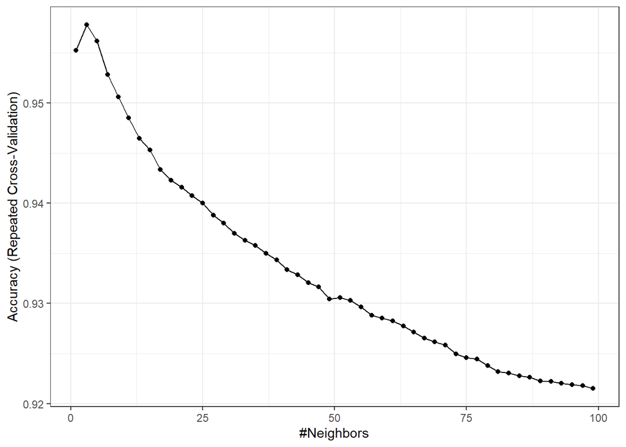

```r
#그래프 그리기
ggplot(knn_fit) +theme_bw()
```

```r
#최종 model을 test set에 적용
cm_test_pred_4 <- predict(knn_fit, cm_test[,-8])
confusionMatrix(cm_test_pred_4, cm_test_labels)
```

```
## Confusion Matrix and Statistics
##
##           Reference
## Prediction Accept Reject
##     Accept     54      4
##     Reject     29    913
##
##                Accuracy : 0.967
##                  95% CI : (0.954, 0.9772)
##     No Information Rate : 0.917
##     P-Value [Acc > NIR] : 9.350e-11
##
##                   Kappa : 0.7488
##
##  Mcnemar's Test P-Value : 2.943e-05
##
##             Sensitivity : 0.6506
##             Specificity : 0.9956
##          Pos Pred Value : 0.9310
##          Neg Pred Value : 0.9692
##              Prevalence : 0.0830
##          Detection Rate : 0.0540
##    Detection Prevalence : 0.0580
##       Balanced Accuracy : 0.8231
##
##        'Positive' Class : Accept
##
```

#### 5-fold cross validation을 5회 실시한 결과 k=3일 때 95.78% Accuracy 가장 뛰어난 값을 가졌다. 3-NN에 적용한 결과 96.7%의 Accuracy, 65.06%의 Sensitivity, 99.56%의 Specificity를 가졌다.

#### 5. 3번과 4번에서 활용한 training 방식의 장단점을 비교해보자.

#### 3번의 경우에 4번보다 시간이 적게 걸린다. 데이터 수가 충분하면 문제는 없겠지만 데이터 수가 부족한 경우 정확한 모델을 얻기가 힘들다. #### 4번의 경우는 교차검증을 통해 평과 결과가 좀 더 정확한 모델을 만들 수 있다. 또한 데이터가 부족할 때 교차검증을 활용한다면 더 정확한 모델을 찾을 수 있다. 하지만 검증 횟수가 많기 때문에 시간이 오래 걸린다는 단점이 있다.